Import Essental libraries

# Project: Investigate Soccer Database

- Introduction
- Data Wrangling
- Exploratory Data Analysis
- Conclusions

## Introduction

> In this report, we will be analysing the Soccer Database, given my personal interest in the sport. This database comes from Kaggle, and it contains data for soccer matches, players, and teams in European countries from 2008 to 2016. In this report, we will mainyl be focusing on teams and their attributes, what attributes and classes are linked to better performing teams. We will be looking to answer the following questions:
1. What is the most improved team between 2014 and 2015?
2. What is the least improved team between 2014 and 2015?
3. What attribute classes are linked to higher winning teams in 2014
4. What attribute classes are linked to higher winning teams in 2015
5. What were the attributes linked to teams with highest wins across all European leagues in 2014?
6. What were the attributes linked to teams with highest wins across all European leagues in 2015?
7. How did the winning teams attributes change between 2014 and 2015?

```python
%matplotlib inline

import pandas as pd
import numpy as np
import matplotlib.pyplot as plt
import sqlite3
```

## Data Wrangling

> We will start by importing all attributes from the database to the notebook, then selecting the data that we are gonna need to answer our questions

### General Properties

Grab data from SQLite database within the folder

```python
db = sqlite3.connect('database.sqlite')
```

```python
matches = pd.read_sql_query('Select * from Match', db)
```

```python
teams = pd.read_sql_query('Select * from Team', db)
```

```python
teams_att = pd.read_sql_query('Select * from Team_Attributes', db)
```

### Cleaning the data

We'll start by removing any null values we have in the dataset

```python
teams = teams.dropna(axis=0, how='any')
teams_att = teams_att.dropna(axis=0, how='any')
```

```python
teams_att['date'].value_counts()
```

```
2015-09-10 00:00:00    245
2014-09-19 00:00:00    244
Name: date, dtype: int64
```

From this we can tell that the attributes were updated in 2014 and 2015

### Merging required Dataframes

Now we merge teams and their attributes

```python
teams_att_cp = teams_att.copy()
teams_att_cp.drop(axis = 1, columns = ['id', 'team_fifa_api_id'], inplace= True)
teams_combined_att = teams.merge(teams_att_cp, on='team_api_id', how='inner')
teams_combined_att.sort_values('team_long_name')
```

|  | id | team_api_id | team_fifa_api_id | team_long_name | team_short_name | date | buildUpPlaySpeed | buildUpPlaySpeedClass | buildUpPlayDribbling | buildUpPlayDribblingClass | ... | chanceCreationShooting | chanceCreationShootingClass | chanceCreationPositioningClass | defencePressure | defencePressureClass | defenceAggression | defenceAggressionClass | defenceTeamWidth | defenceTeamWidthClass | defenceDefenderLineClass |
| --- | --- | --- | --- | --- | --- | --- | --- | --- | --- | --- | --- | --- | --- | --- | --- | --- | --- | --- | --- | --- | --- |
| 205 | 16848 | 8350 | 29.0 | 1. FC Kaiserslautern | KAI | 2014-09-19 00:00:00 | 66 | Balanced | 48.0 | Normal | ... | 51 | Normal | Organised | 47 | Medium | 47 | Press | 49 | Normal | Cover |
| 206 | 16848 | 8350 | 29.0 | 1. FC Kaiserslautern | KAI | 2015-09-10 00:00:00 | 49 | Balanced | 54.0 | Normal | ... | 64 | Normal | Organised | 41 | Medium | 51 | Press | 53 | Normal | Cover |
| 180 | 15624 | 8722 | 31.0 | 1. FC Köln | FCK | 2015-09-10 00:00:00 | 59 | Balanced | 47.0 | Normal | ... | 71 | Lots | Organised | 42 | Medium | 56 | Press | 51 | Normal | Cover |
| 179 | 15624 | 8722 | 31.0 | 1. FC Köln | FCK | 2014-09-19 00:00:00 | 59 | Balanced | 53.0 | Normal | ... | 59 | Normal | Organised | 57 | Medium | 46 | Press | 54 | Normal | Cover |
| 201 | 16239 | 8165 | 171.0 | 1. FC Nürnberg | NUR | 2014-09-19 00:00:00 | 46 | Balanced | 62.0 | Normal | ... | 55 | Normal | Organised | 51 | Medium | 50 | Press | 47 | Normal | Cover |
| ... | ... | ... | ... | ... | ... | ... | ... | ... | ... | ... | ... | ... | ... | ... | ... | ... | ... | ... | ... | ... | ... |
| 345 | 33855 | 8027 | 112512.0 | Zawisza Bydgoszcz | ZAW | 2015-09-10 00:00:00 | 54 | Balanced | 51.0 | Normal | ... | 52 | Normal | Organised | 44 | Medium | 47 | Press | 52 | Normal | Cover |
| 148 | 11822 | 4087 | 111271.0 | Évian Thonon Gaillard FC | ETG | 2014-09-19 00:00:00 | 61 | Balanced | 51.0 | Normal | ... | 48 | Normal | Organised | 47 | Medium | 56 | Press | 50 | Normal | Cover |
| 149 | 11822 | 4087 | 111271.0 | Évian Thonon Gaillard FC | ETG | 2015-09-10 00:00:00 | 58 | Balanced | 35.0 | Normal | ... | 51 | Normal | Organised | 47 | Medium | 43 | Press | 50 | Normal | Cover |
| 322 | 31449 | 8025 | 111092.0 | Śląsk Wrocław | SLA | 2014-09-19 00:00:00 | 47 | Balanced | 53.0 | Normal | ... | 68 | Lots | Organised | 37 | Medium | 37 | Press | 39 | Normal | Cover |
| 323 | 31449 | 8025 | 111092.0 | Śląsk Wrocław | SLA | 2015-09-10 00:00:00 | 50 | Balanced | 55.0 | Normal | ... | 55 | Normal | Organised | 45 | Medium | 55 | Press | 39 | Normal | Cover |

489 rows × 27 columns

**for each team, add the number of goals scored, goals consieved, matches won, tied, and lost**

```python
def increment_stats(teams, home_index, away_index, home_goals, away_goals):

    teams.at[away_index, 'goals_scored'] += away_goals
    teams.at[away_index, 'goals_conceived'] += home_goals

    teams.at[home_index, 'goals_scored'] += home_goals
    teams.at[home_index, 'goals_conceived'] += away_goals

    if home_goals > away_goals:
        teams.at[home_index, 'matches_won'] += 1
        teams.at[away_index, 'matches_lost'] += 1

    elif home_goals < away_goals:
        teams.at[home_index, 'matches_lost'] += 1
        teams.at[away_index, 'matches_won'] += 1

    elif home_goals == away_goals:
        teams.at[home_index, 'matches_drawn'] += 1
        teams.at[away_index, 'matches_drawn'] += 1

    teams.at[home_index, 'matches_played'] += 1
    teams.at[away_index, 'matches_played'] += 1

    return teams
```

```python
new_teams = teams.copy()
#insert required columns
new_teams.insert(5, 'goals_scored', 0)
new_teams.insert(6, 'goals_conceived', 0)
new_teams.insert(7, 'matches_played', 0)
new_teams.insert(8, 'matches_won', 0)
new_teams.insert(9, 'matches_drawn', 0)
new_teams.insert(10, 'matches_lost', 0)

#create 2 dataframes and edit their information
teams_2014 = new_teams.copy()
teams_2015 = new_teams.copy()


for index, row in matches.iterrows():
    #get the home team and the away team from the match
    away_team = new_teams[new_teams['team_api_id'] == row['away_team_api_id']]
    home_team = new_teams[new_teams['team_api_id'] == row['home_team_api_id']]
    away_index = None
    home_index = None
    #the index of both teams in the database (to save processing time)
    if not home_team.empty and not away_team.empty:
        home_index = home_team.index.values.astype(int)[0]
        away_index = away_team.index.values.astype(int)[0]
    else:
        continue

    away_goals = row['away_team_goal']
    home_goals = row['home_team_goal']

    #increment all information in new_teamsn, and 2014 and 2015 dates in their relative variables
    new_teams = increment_stats(new_teams, home_index, away_index, home_goals, away_goals)
    if row['date'] >= '2014-09-19 00:00:00' and row['date'] < '2015-09-10 00:00:00':
        teams_2014 = increment_stats(teams_2014, home_index, away_index, home_goals, away_goals)

    if row['date'] >= '2015-09-10 00:00:00' and row['date'] < '2016-09-10 00:00:00':
        teams_2015 = increment_stats(teams_2015, home_index, away_index, home_goals, away_goals)
```

Remove any team with less than 10 games, so keep the standard deviation at an acceptable level

```python
teams_2014_clean = teams_2014[teams_2014['matches_played'] > 10]
teams_2015_clean = teams_2015[teams_2015['matches_played'] > 10]
```

No we get the extra information required to analyse team performances, information such as

1. Wins per game
2. Draws per game
3. Losses per game
4. Points
5. Points per game

This is important in order to keep the number normalized, as some teams played more game than other

```python
def get_points_matches(in_teams):
    teams = in_teams.copy()
    teams.insert(11, 'wpg', 0.0)
    teams.insert(12, 'dpg', 0.0)
    teams.insert(13, 'lpg', 0.0)
    teams.insert(14, 'points', 0)
    teams.insert(15, 'ppg', 0.0)

    for index, team in teams.iterrows():
        teams.at[index, 'wpg'] = team['matches_won']/team['matches_played']
        teams.at[index, 'dpg'] = team['matches_drawn']/team['matches_played']
        teams.at[index, 'lpg'] = team['matches_lost']/team['matches_played']
        teams.at[index, 'points'] = team['matches_won'] *3 + team['matches_drawn']
        teams.at[index, 'ppg'] = teams.at[index, 'points']/team['matches_played']
    return teams
```

```python
teams_2014_points = get_points_matches(teams_2014_clean)
```

```python
teams_2015_points = get_points_matches(teams_2015_clean)
```

add _2014 identifier to 2014 attributes and merge with 2015 data

```python
team_matches_2014 = teams_2014_points[['team_api_id', 'team_long_name', 'team_short_name', 'matches_played', 'matches_won', 'matches_drawn', 'matches_lost', 'points', 'ppg']].copy()

team_matches_2014.rename(columns=lambda x: x + "_2014", inplace=True)

team_matches_2015 = teams_2015_points[['team_api_id', 'team_long_name', 'team_short_name', 'matches_played', 'matches_won', 'matches_drawn', 'matches_lost', 'points', 'ppg']].copy()
team_matches_2015


teams_combined = team_matches_2014.merge(team_matches_2015, left_on= 'team_api_id_2014', right_on='team_api_id', how = 'inner')
len(teams_combined.columns)
```

```
18
```

Create a points per game difference column for each team, with difference between 2014 and 2015

```python
for index, row in teams_combined.iterrows():
    teams_combined.at[index, 'ppg_diff'] = row['ppg'] - row['ppg_2014']
teams_combined.head()
```

|  | team_api_id_2014 | team_long_name_2014 | team_short_name_2014 | matches_played_2014 | matches_won_2014 | matches_drawn_2014 | matches_lost_2014 | points_2014 | ppg_2014 | team_api_id | team_long_name | team_short_name | matches_played | matches_won | matches_drawn | matches_lost | points | ppg | ppg_diff |
| --- | --- | --- | --- | --- | --- | --- | --- | --- | --- | --- | --- | --- | --- | --- | --- | --- | --- | --- | --- |
| 0 | 9987 | KRC Genk | GEN | 29 | 15 | 6 | 8 | 51 | 1.758621 | 9987 | KRC Genk | GEN | 24 | 11 | 5 | 8 | 38 | 1.583333 | -0.175287 |
| 1 | 10000 | SV Zulte-Waregem | ZUL | 29 | 10 | 5 | 14 | 35 | 1.206897 | 10000 | SV Zulte-Waregem | ZUL | 24 | 9 | 6 | 9 | 33 | 1.375000 | 0.168103 |
| 2 | 9994 | Sporting Lokeren | LOK | 29 | 8 | 12 | 9 | 36 | 1.241379 | 9994 | Sporting Lokeren | LOK | 24 | 7 | 8 | 9 | 29 | 1.208333 | -0.033046 |
| 3 | 8635 | RSC Anderlecht | AND | 29 | 16 | 7 | 6 | 55 | 1.896552 | 8635 | RSC Anderlecht | AND | 24 | 11 | 9 | 4 | 42 | 1.750000 | -0.146552 |
| 4 | 9991 | KAA Gent | GEN | 29 | 14 | 12 | 3 | 54 | 1.862069 | 9991 | KAA Gent | GEN | 24 | 15 | 5 | 4 | 50 | 2.083333 | 0.221264 |

Create a list for 2014 teams and merge their attributes

```python
teams_2014_att = teams_combined_att[teams_combined_att['date'].str.contains('2014')]
```

Drop duplicated columns in 2014 and 2015 before merging in order to reduce the number of unnecessary columns in the resulting df

```python
delete_columns = ['id', 'team_fifa_api_id', 'team_long_name', 'team_short_name', 'date']

teams_2014_att.drop(columns = delete_columns, inplace=True)
```

```python
teams_2015_att = teams_combined_att[teams_combined_att['date'].str.contains('2015')]
teams_2015_att.drop(columns = delete_columns, inplace=True)
```

```python
teams_2014_att.rename(columns=lambda x: x + "_2014", inplace=True)
```

```python
team_att_combined = teams_2015_att.merge(teams_2014_att, right_on = 'team_api_id_2014', left_on = 'team_api_id', how = 'inner')
```

Merge matches/points/goals with attributes for each year

```python
teams_2014_all = teams_2014_points.merge(teams_2014_att, left_on = 'team_api_id', right_on = 'team_api_id_2014')
```

Split the df into two dfs with high win teams on one side, and low win teams on the other

```python
def split_teams_wpg(teams, non_crucial_cols, ext):

    mean_wpg = teams['wpg'].mean()

    high_win_teams = teams[teams['wpg'] >= mean_wpg]
    low_win_teams = teams[teams['wpg'] < mean_wpg]

    return high_win_teams, low_win_teams
```

```python
teams_2015_all = teams_2015_points.merge(teams_2015_att, on = 'team_api_id')

non_crucial_cols = ['id', 'team_api_id', 'team_fifa_api_id', 'date']
high_win_teams_2015, low_win_teams_2015 = split_teams_wpg(teams_2015_all, non_crucial_cols, "")
```

```python
high_win_teams_2014, low_win_teams_2014 = split_teams_wpg(teams_2014_all, non_crucial_cols, "_2014")
```

get the max improved tea using idxmax and the minimum using idxmin from the combined teams df

```python
max_team = teams_combined.iloc[teams_combined['ppg_diff'].idxmax()]
max_imp = max_team['ppg_diff']
mean_imp = teams_combined['ppg_diff'].mean()

max_values = [max_imp, mean_imp]
max_labels = [max_team['team_long_name'], 'Mean']


min_team = teams_combined.iloc[teams_combined['ppg_diff'].idxmin()]
min_imp = min_team['ppg_diff']

min_values = [min_imp, mean_imp]
min_labels = [min_team['team_long_name'], 'Mean']
```

Plot min and max values

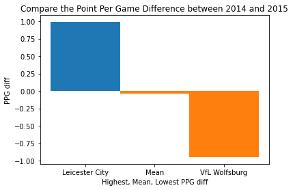

```python
#labels, values = zip(*graph)
indexes = np.arange(2)
width = 1

plt.bar(max_labels, max_values, width)
plt.bar(min_labels, min_values, width)
plt.title('Compare the Point Per Game Difference between 2014 and 2015')
plt.xlabel('Highest, Mean, Lowest PPG diff')
plt.ylabel('PPG diff')
```

### Points per game difference between 2014 and 2015

**What is the most improved team between 2014 and 2015?**

From this we can note that the team with the biggest improvement is Leicester City, as they increased by 0.99 points per game, compared to the average of -0.039 points per game (ppg) difference

**What is the least improved team between 2014 and 2015?**

The least improved team is VfL wolvesburg, with a ppg difference of -0.95 points per game between 2014 and 2015

Receives highest winning and lowest winning team dfs, the titles of each chart, and the super title

```python
def compare_classes(winning_teams, losing_teams, start, winning_title, losing_title, suptitle):
    #create a plot with 24 subplots (12, 2 for each side). compare winning and losing team
    fig, ax = plt.subplots(12,2, figsize = (50,150))
    #Note that both high wins and low wins share the same df structure
    columns = winning_teams.columns
    #first index of classes, should be incremented by 2 each time
    col_index = start
    for x in ax:
        #In the last number of indices, anything that does not have 'class' in its name is an attribute
        while(not 'Class' in columns[col_index]):
            col_index += 1

        #get the values and labels of the winning teams
        w_values = winning_teams[columns[col_index]].value_counts(normalize = True)
        w_labels = w_values.keys()


        if('_2014' in columns[col_index]):
            att_name = columns[col_index][:-5]
        else:
            att_name = columns[col_index]

        x[0].set_title(winning_title+' '+att_name, fontsize = 40)

        #create bar for losing teams
        l_values = losing_teams[columns[col_index]].value_counts(normalize = True)
        l_labels = l_values.keys()


        x[1].set_title(losing_title+' '+att_name, fontsize = 40)

        #create a list of unique labels
        labels = list(set(w_labels.append(l_labels)))

        #if label does not exist in the list, create a series and add a 0 value
        new_w_labels = [label for label in labels if label not in w_labels]
        new_w_values = [0] * len(new_w_labels)
        new_w_values = pd.Series(new_w_values, new_w_labels)
        #add the series of missing values/labels
        w_values.add(new_w_values)


        new_l_labels = [label for label in labels if label not in l_labels]
        new_l_values = [0] * len(new_l_labels)
        new_l_values = pd.Series(new_l_values, new_l_labels)

        l_values.add(new_l_values)

        l_labels = l_values.keys()

        #Create bar graph for both winning and losing teams
        ypos = np.arange(len(w_labels))
        x[0].set_xticks(ypos)
        x[0].set_xticklabels(w_labels, fontsize = 25)
        x[0].set_xlabel('Attribute Class', fontsize = 25)
        x[0].set_ylabel('Attribute Ratio', fontsize = 25)
        x[0].set_ylim([0, 1])
        x[0].bar(ypos, w_values)


        ypos = np.arange(len(l_labels))
        x[1].set_xticks(ypos)
        x[1].set_xticklabels(l_labels, fontsize = 25)
        x[1].set_ylim([0, 1])
        x[1].bar(ypos, l_values)

        col_index += 1
    fig.suptitle(suptitle, fontsize = 64)
```

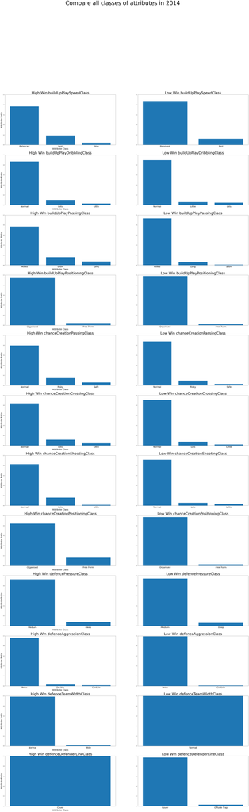

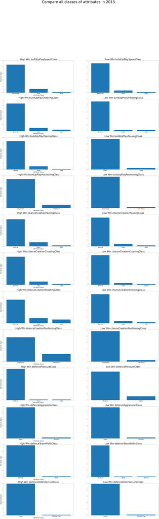

```python
compare_classes(high_win_teams_2014, low_win_teams_2014, high_win_teams_2014.columns.get_loc('buildUpPlaySpeed_2014'), "High Win", "Low Win", "Compare all classes of attributes in 2014")

compare_classes(high_win_teams_2015, low_win_teams_2015, high_win_teams_2015.columns.get_loc('buildUpPlaySpeed'), "High Win", "Low Win", "Compare all classes of attributes in 2015")
```

### Attribute Class Analysis

**What attribute classes are linked to higher winning teams in 2014**

In 2014, teams with greater winning ratios are more reliant on short passes, as opposed to the generally mixed passes from the lower winning teams. Additionally, teams with greater win rate create more chances from shooting and have a more free form of postisioning.

**What attribute classes are linked to higher winning teams in 2015**

In 2015, higher winning teams still created more chances using short passes and less long passes than lower winning teams. However, the emphasis on chance creation by shooting had reduced in higher winning teams compared to that in 2014.

Compare the mean of each atribute and create a bar chart for winning and losing teams

```python
def compare_mean_atts(winning_teams, losing_teams, start, winning_title, losing_title, suptitle):

    all_columns = winning_teams.columns
    labels = []

    #Used to create a list of means, which will be graphed
    high_win_means = []
    low_win_means = []

    for column in all_columns[start:]:
        if not 'Class' in column:
            #Append non-class attributes
            high_win_means.append(winning_teams[column].mean())
            low_win_means.append(losing_teams[column].mean())

            if '_2014' in column:
                label = column[:-5]
            else:
                label = column
            #Select the essentials of the label, so avoid large labels
            label = label[0].upper() + label[1:]
            label = ''.join([letter for letter in label if letter.isupper()])
            labels.append(label)
    #Create 2 bar charts, one for high winning, and one for low winning
    ypos = np.arange(len(labels))
    width = 0.35

    high_win_bar = plt.bar(ypos, high_win_means, width, color = 'r', alpha = .7, label = winning_title)
    low_win_bar = plt.bar(ypos+width/2, low_win_means, width, color = 'b', alpha = .7, label = losing_title)

    plt.ylabel('Attribute Means')
    plt.xlabel('Attribute Abbreviations')
    plt.title(suptitle)
    locations = ypos+ width/2
    plt.xticks(locations, labels)
    plt.ylim([0, 70])


    plt.legend()
    return plt
```

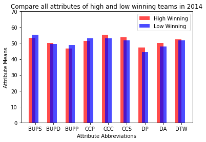

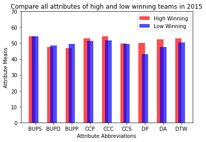

```python
plt1 = compare_mean_atts(high_win_teams_2014, low_win_teams_2014, high_win_teams_2014.columns.get_loc('buildUpPlaySpeed_2014'), "High Winning", "Low Winning", "Compare all attributes of high and low winning teams in 2014")
plt.show()
plt2 = compare_mean_atts(high_win_teams_2015, low_win_teams_2015, high_win_teams_2015.columns.get_loc("buildUpPlaySpeed"), "High Winning", "Low Winning", "Compare all attributes of high and low winning teams in 2015")
plt.show()
```

```python
#teams_2015_all.plot.scatter(x='goals_scored', y='ppg', title = "Compare goals scored against points per game")
```

### Attribute Rating Analysis

**What were the attributes linked to teams with highest wins across all European leagues in 2015?**

In 2015, higher winning teams had higher ratings in a different set of 6 attributes of the 9 available (namely, Chance Creation Passing, Chance Creation Crossing, Chance Creation Shooting, Defence Pressure, Defence Aggression, and Defence Team Width) with the biggest difference in Defence Pressure with 7.0 rating difference between highest winning and lowest winning teams.

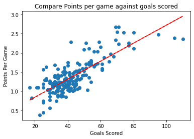

```python
x = teams_2015_all['goals_scored']
y = teams_2015_all['ppg']
plt.scatter(x,y)
plt.xlabel('Goals Scored')
plt.ylabel('Points Per Game')
plt.title('Compare Points per game against goals scored')
z = np.polyfit(x, y, 1)
p = np.poly1d(z)
plt.plot(x, p(x), "r--")
```

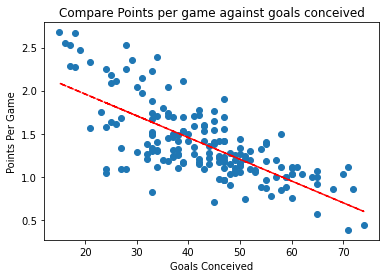

```python
x = teams_2015_all['goals_conceived']
y = teams_2015_all['ppg']
plt.scatter(x,y)
plt.xlabel('Goals Conceived')
plt.ylabel('Points Per Game')
plt.title('Compare Points per game against goals conceived')
z = np.polyfit(x, y, 1)
p = np.poly1d(z)
plt.plot(x, p(x), "r--")
```

### Attribute Rating Analysis

**Does scoring more goal always mean winning more games?**

Generally, scoring more goals does make you win more games as given by the trendline above, but we do however see teams that score less get more points than better attacking teams, meaning that defence also has a significant importance in the overall performance, not just scoring more goals, but keeping your goal clear.

**Does defending better always means more points?**

As shown by the graph, defending better generally yields more points as shown by the trendline, but there are many teams that conceive more goals that score more points, giving importance to attacking.

In general, it is important to balance between attacking and defending

## Conclusions

In conclusion, we have reviewed the best improve, and the worst improved team between 2014 and 2015 by investigating their Points Per Page and comparing them to them mean PPG change. Then we discussed how attribute classes effect matches in both 2014 and 2015, and compared the difference in these classes between teams with higher wins and teams with lower wins. We then investigated the attributes even further, noting that Higher winning teams are generally rated higher for most of the attributes, but there were 3 attributes that was rated lower for higher winning teams than lower winning teams. We also covered slight changes in these attributed between 2014 and 2015. Finally, we reveiwed how scoring and conceiving goals effect the amount of points a team can grab.

**Limitations:**

This data is limited to 2 years of data, 2014 and 2015, which greatly harms and lowers the accuracy of the data.

*The remaining bits are left for my reference.*

```python
def create_bar(team1, team2, title1, title2, suptitle):
    fig, (ax1, ax2) = plt.subplots(1,2, figsize = (10,5))


    values1 = team1.value_counts(normalize = True)
    labels1 = values1.keys()


    x[0].set_title(title1)

    values2 = team2.value_counts(normalize = True)
    labels2 = values2.keys()

    x[1].set_title(title2)

    #labels have the same order
    labels = list(set(w_labels.append(l_labels)))
    labels1 = [label for label in labels if label in labels1]
    labels2 = [label for label in labels if label in labels2]

    ypos = np.arange(len(w_labels))
    ax1.set_xticks(ypos)
    ax1.set_xticklabels(w_labels)
    ax1.set_ylim([0, 1])
    ax1.bar(ypos, values1)


    ypos = np.arange(len(labels2))
    ax2.set_xticks(ypos)
    ax2.set_xticklabels(labels2)
    ax2.set_ylim([0, 1])
    ax2.bar(ypos, values2)


    fig.suptitle(suptitle, fontsize = 16)
```

```python
def get_labels(values):
    labels = []
    for value in values:
        if(value.index not in labels):
            labels.append(values[values==value].index)
    return labels
```

```python
#create_bar(high_win_teams_2014['buildUpPlaySpeedClass_2014'], low_win_teams_2014['buildUpPlaySpeedClass_2014'], title1 = 'Highest Winning Teams', title2 = 'Lowest Winning Teams', suptitle = 'Compare Play Up Speed Classes')
```

```python
#create_bar(high_win_teams_2014['buildUpPlayDribblingClass_2014'], low_win_teams_2014['buildUpPlayDribblingClass_2014'], title1 = 'Highest Winning Teams', title2 = 'Lowest Winning Teams', suptitle = 'Compare Play Up Dribbling Classes')
```

```python
#create_bar(high_win_teams_2014['buildUpPlayPassingClass_2014'], low_win_teams_2014['buildUpPlayPassingClass_2014'], title1 = 'Highest Winning Teams', title2 = 'Lowest Winning Teams', suptitle = 'Compare Play Up Passing Classes')
```

```python
#create_bar(high_win_teams_2014['buildUpPlayPClass_2014'], low_win_teams_2014['buildUpPlayPassingClass_2014'], title1 = 'Highest Winning Teams', title2 = 'Lowest Winning Teams', suptitle = 'Compare Play Up Passing Classes')
```

```python
#fig, (ax1, ax2) = plt.subplots(1,2, figsize = (10,5))



#values1 = high_win_teams_2014['buildUpPlayPassingClass_2014'].value_counts(normalize = True)
# print(type(values))
# labels1 = values1.keys()


# ax1.set_title('Highest winning teams')


# values2 = low_win_teams_2014['buildUpPlayPassingClass_2014'].value_counts(normalize = True)
# labels2 = values2.keys()

# ax2.set_title('Lowest winning teams')
# ax2.set_ylim([0, 1])

# labels = list(set(labels1.append(labels2)))


# ax1.pie(values1, labels = [label for label in labels if label in labels1])
# ax2.pie(values2, labels = [label for label in labels if label in labels2])


# fig.suptitle('Compare Play Up Passing Classes', fontsize = 16)
```

```python
def compare_mean_atts2(winning_teams, losing_teams, winning_title, losing_title, suptitle):
    fig, ax = plt.subplots(12,1, figsize = (10,100))
    #Note that both high wins and low wins share the same df structure
    columns = winning_teams.columns
    #first index of classes, should be incremented by 2 each time
    col_index = 17
    for x in ax:

        while(col_index < len(columns) and 'Class' in columns[col_index]):
            col_index += 1
        if col_index >= len(columns):
            break
        values = [winning_teams[columns[col_index]].mean(), losing_teams[columns[col_index]].mean()]
        if '_2014' in columns[col_index]:
            att_name = columns[col_index][:-5]
        else:
            att_name = columns[col_index]

        labels = [winning_title, losing_title]

        ypos = np.arange(len(labels))
        x.set_xticks(ypos)
        x.set_xticklabels(labels)
        x.set_ylim([0, 100])
        x.bar(ypos, values, 0.75, color = 'blue')

        x.set_title('Comparing '+att_name)


        col_index += 1
    return fig, ax
```